# Project Python Foundations: FoodHub Data Analysis

### Observations of Delivery Time:

From the histogram above, it shows that it takes about 15 to 33 minutes to deliver food. The distribution peaks around 20,25,28 minutes but is fairly even throughout. From the box plot, it shows that the median time it takes to deliver food is 25 minutes. The IQR is between 20 to 28 minutes, which means most of the delivery orders are delivered within that range. There are no outliers as seen from the box plot above. From the plots above, it takes around 20-28 minutes to deliver food.

**Categorical Columns:**

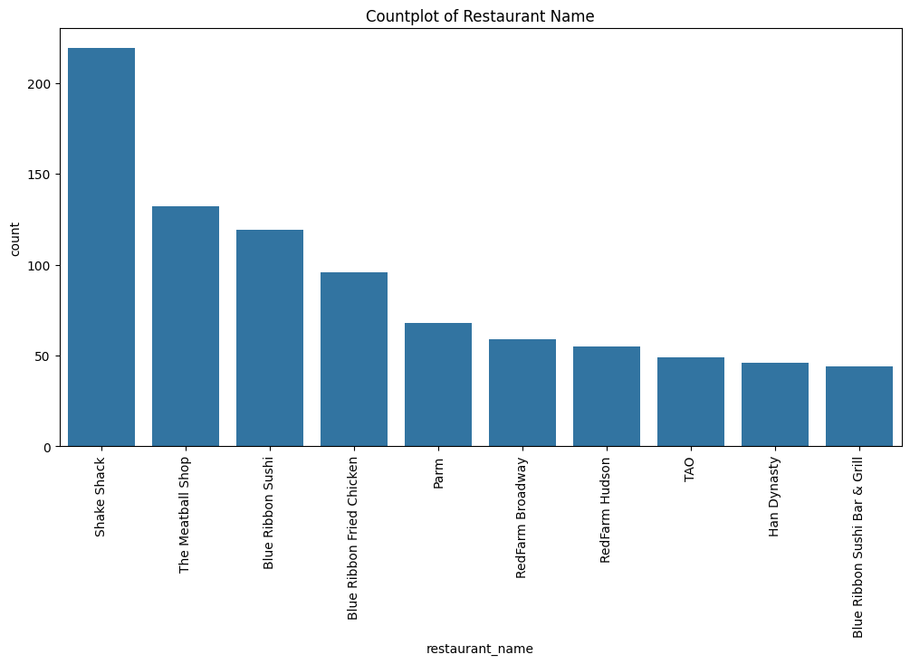

```python
plt.figure(figsize =(12, 6))
sns.countplot(data =df, x = 'restaurant_name',
              order = df['restaurant_name'].value_counts().head(10).index)
plt.title('Countplot of Restaurant Name')
plt.xticks(rotation = 90);
```

### Observations of restaurant name:

From the countplot seen above, Shake Shack is the most popular restaurant, with the highest number of orders. The Meatball Shop and Blue Ribbon Sushi and also the second and third highest restaurants that customers order from, following by Blue Ribbon Fried Chicken with good number of orders.

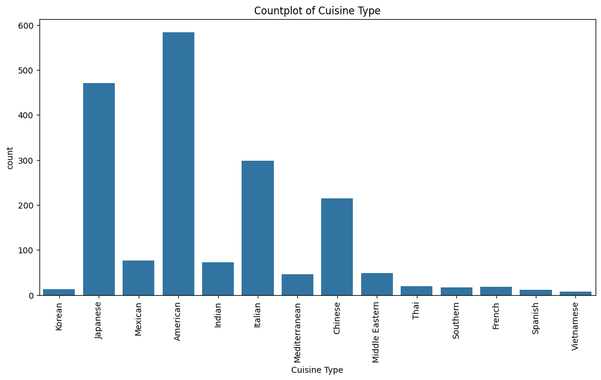

```python
plt.figure(figsize=(12, 6))
sns.countplot(data=df, x='cuisine_type')
plt.title('Countplot of Cuisine Type')
plt.xlabel('Cuisine Type')
plt.xticks(rotation=90)
plt.show()
```

### Observations of Cuisine Type:

From the countplot above, the highest orders are from American cuisine, around 580 orders and looks the most popular among customers. The second most popular is the Japanese cuisine with around 470 orders. The third popular are Italian and Chinese cuisines, and other cuisines are relatively lower.

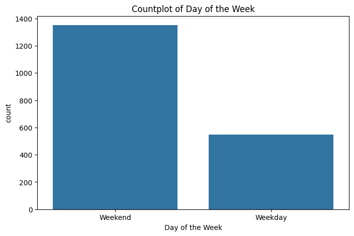

```python
plt.figure(figsize=(8, 5))
sns.countplot(data=df, x='day_of_the_week')
plt.title('Countplot of Day of the Week')
plt.xlabel('Day of the Week')
plt.show()
```

### Observations of Day of the Week:

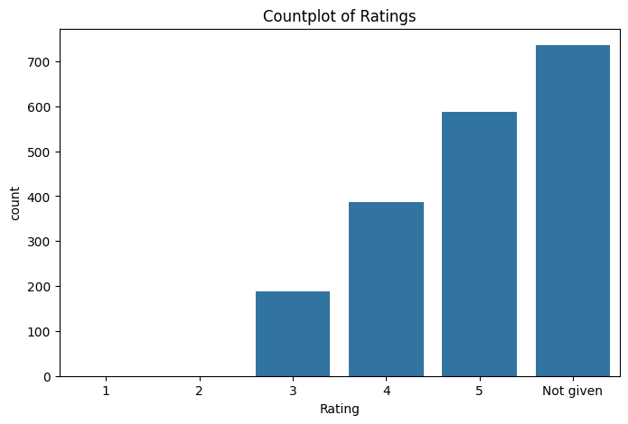

```python
plt.figure(figsize=(8, 5))
order = [1, 2, 3, 4, 5, 'Not given']
sns.countplot(data=df, x='rating', order=order)
plt.title('Countplot of Ratings')
plt.xlabel('Rating')
plt.show()
```

### **Question 7**: Which are the top 5 restaurants in terms of the number of orders received? [1 mark]

```python
df['restaurant_name'].value_counts().head()
```

| restaurant_name | count |
| --- | --- |
| Shake Shack | 219 |
| The Meatball Shop | 132 |
| Blue Ribbon Sushi | 119 |
| Blue Ribbon Fried Chicken | 96 |
| Parm | 68 |

**dtype:** int64

#### Observations:

Top 5 restaurants by number of orders received are Shake Shack, The Meatball Shop, Blue Ribbon Sushi, Blue Ribbon Fried Chicken, and Parm.

### **Question 8**: Which is the most popular cuisine on weekends? [1 mark]

```python
weekend_orders = df[df['day_of_the_week'] == 'Weekend']
popular_cuisine_weekends = weekend_orders['cuisine_type'].value_counts().idxmax()

print("The most popular cuisine on weekends is:", popular_cuisine_weekends)
```

```
The most popular cuisine on weekends is: American
```

#### Observations:

The most popular cuisine on weekends is American cuisine.

### **Question 9**: What percentage of the orders cost more than 20 dollars? [2 marks]

```python
percentage_above_20 = round(100*len(df[df['cost_of_the_order'] > 20])/len(df),2)

print(f"Percentage of orders costing more than $20: {percentage_above_20:.2f}%")
```

```
Percentage of orders costing more than $20: 29.24%
```

#### Observations:

29.24% of orders cost more than 20 dollars.

### **Question 10**: What is the mean order delivery time? [1 mark]

```python
mean_delivery_time = df['delivery_time'].mean()
print(f"Mean order delivery time: {mean_delivery_time:.2f} minutes")
```

```
Mean order delivery time: 24.16 minutes
```

#### Observations:

The average delivery time of the order is around 24 minutes.

### **Question 11:** The company has decided to give 20% discount vouchers to the top 5 most frequent customers. Find the IDs of these customers and the number of orders they placed. [1 mark]

```python
df['customer_id'].value_counts().head(5)
```

| customer_id | count |
| --- | --- |
| 52832 | 13 |
| 47440 | 10 |
| 83287 | 9 |
| 250494 | 8 |
| 259341 | 7 |

**dtype:** int64

#### Observations:

As seen above, top 5 most frequent customers and their number of orders they placed are:

Customer ID: 52832 with 13 orders; Customer ID: 47440 with 10 orders; Customer ID: 83287 with 9 orders; Customer ID: 250494 with 8 orders; Customer ID: 259341 with 7 orders.

### **Question 12**: Perform a multivariate analysis to explore relationships between the important variables in the dataset. (It is a good idea to explore relations between numerical variables as well as relations between numerical and categorical variables) [10 marks]

**Heatmap for correlations of all numerical columns**

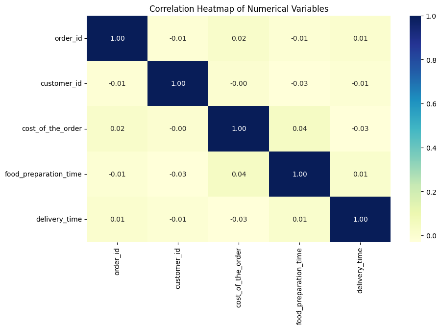

```python
plt.figure(figsize=(10, 6))
sns.heatmap(df.select_dtypes(include=np.number).corr(), annot=True, fmt=".2f", cmap="YlGnBu")
plt.title('Correlation Heatmap of Numerical Variables')
plt.show()
```

#### Observations:

From the heat map shown above, there is a low to no correlation between all variables, as most of the variables are close to 0. Cost of the order and food preparation time have slightly positive relation of 0.04, but it is not much. It shows that most of the numerical values are not dependent of each other.

**Pair plots of all numerical columns**

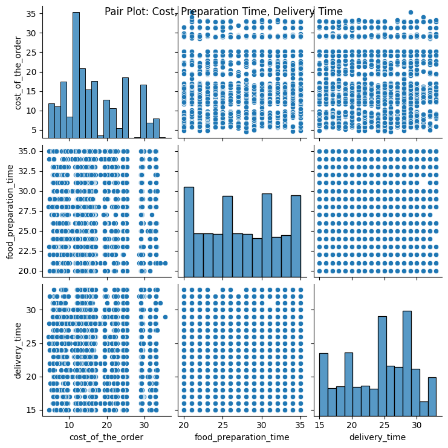

```python
sns.pairplot(df[['cost_of_the_order','food_preparation_time','delivery_time']])
plt.suptitle("Pair Plot: Cost, Preparation Time, Delivery Time")
plt.show()
```

#### Observations:

**Joint Plot of Cost of order and Delivery Time**

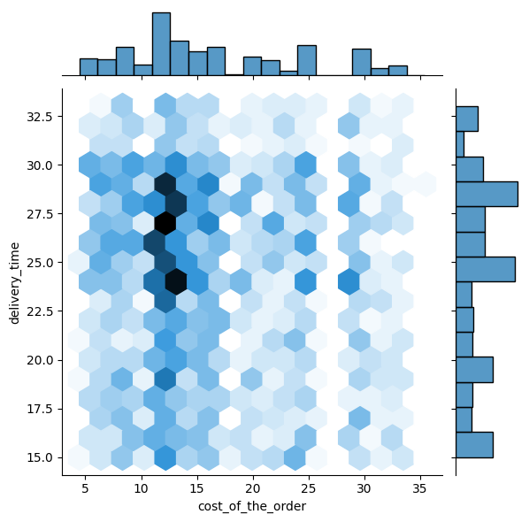

```python
plt.figure(figsize =(12, 6));
sns.jointplot(data = df, x = 'cost_of_the_order', y ='delivery_time', kind= 'hex');
plt.show()
```

#### Observations:

From the joint plot above, it shows that customers mostly place orders that cost around 10-15 dollars, which are delivered in around 25-30 minutes. Other than that, it shows that delivery time is fairly stable.

**Box Plot of Delivery Time and Day of the Week**

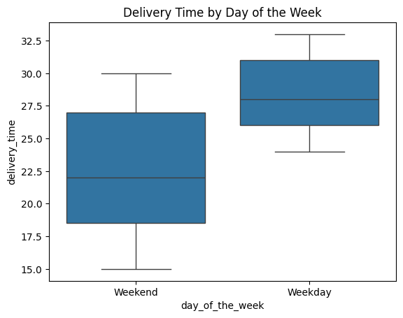

```python
sns.boxplot(data=df, x='day_of_the_week', y='delivery_time')
plt.title("Delivery Time by Day of the Week")
plt.show()
```

#### Observations:

From the box plot above, it shows that deliveries take longer on weekdays than on weekends, as the median delivery time on weekdays is around 28 minutes, and median delivery time on weekends is 22 minutes. On weekdays the spread (IQR) is smaller, which means the delivery times are more consistent and on weekends the spread (IQR) is wider, which means there is more variation in delivery times. There are no outliers shown above.

**Box Plot of Cost of the order and Cuisine Type**

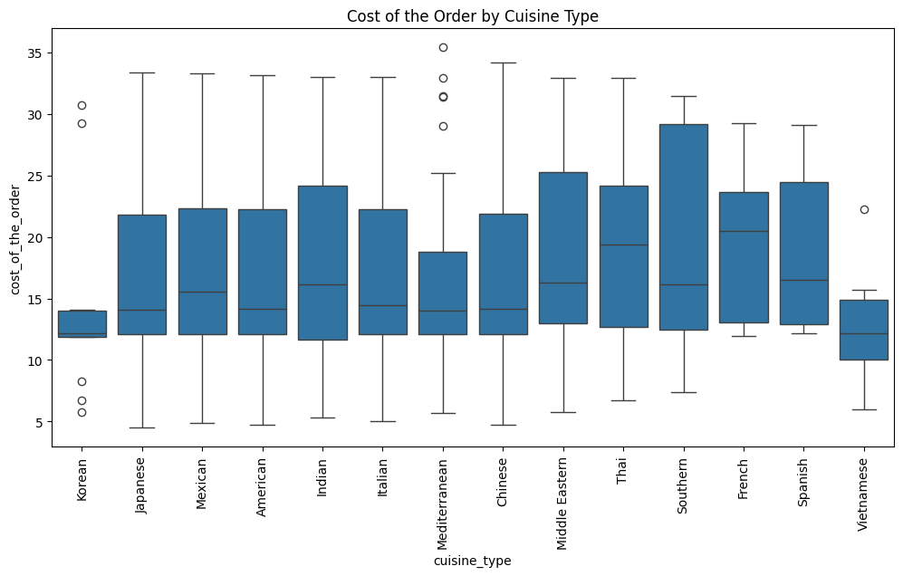

```python
plt.figure(figsize=(12,6))
sns.boxplot(data=df, x='cuisine_type', y='cost_of_the_order')
plt.xticks(rotation=90)
plt.title("Cost of the Order by Cuisine Type")
plt.show()
```

#### Observations:

From the box plot above, it shows that Southern, French, Thai, and Spanish cuisines orders cost more than the Korean and Vietnamese cuisines as they are the cheapest in price. However, Korean, Mediterranean and Vietnamese cuisines have outliers, which means there are some high cost orders that exist too. Cuisines like Thai, Southern, Spanish, and French their spreads (IQR) are very large, which means their costs vary from cheap to expensive options.

**Box Plot of Cost of the order and Rating**

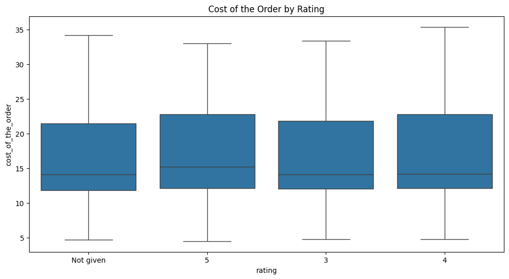

```python
plt.figure(figsize=(12,6))
sns.boxplot(data=df, x='rating', y='cost_of_the_order')
plt.title("Cost of the Order by Rating")
plt.show()
```

#### Observations:

From the box plot above, it shows that order cost is not a strong factor in determining the customer ratings. Even if the customer spends less or high, the range of the ratings will be between 3-5.

**Box Plot Cost of the Order and Day of the Week**

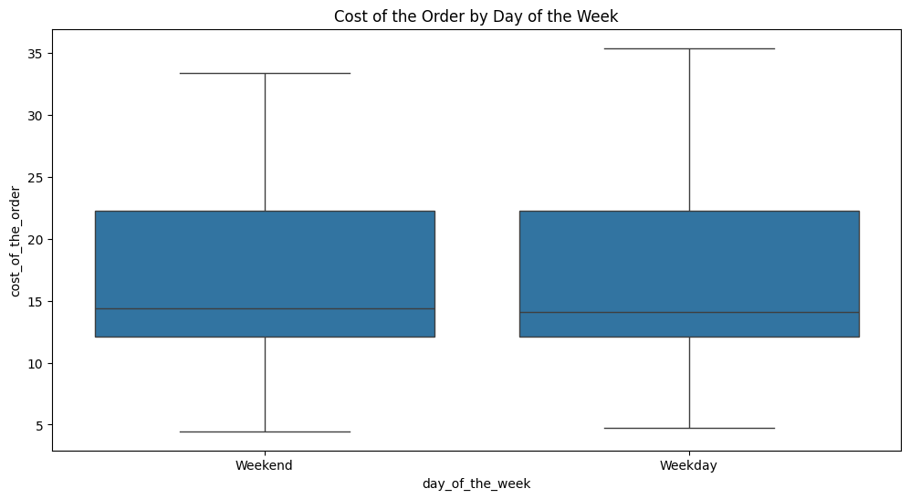

```python
plt.figure(figsize=(12,6))
sns.boxplot(data=df, x='day_of_the_week', y='cost_of_the_order')
plt.title("Cost of the Order by Day of the Week")
plt.show()
```

#### Observations:

From the box plot above, it shows that the median cost of the order is almost the same for weekdays and weekends, which means the customers spend the same amount regardless of the day of the week.

**Countplot of Cuisine and Day of the Week**

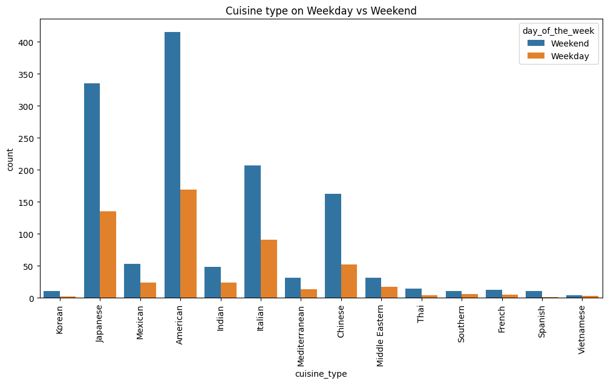

```python
plt.figure(figsize=(12,6))
sns.countplot(data=df, x='cuisine_type', hue='day_of_the_week')
plt.xticks(rotation=90)
plt.title("Cuisine type on Weekday vs Weekend")
plt.show()
```

#### Observations:

From the countplot above, it is clearly shown that people order more food on weekends than weekdays for almost every cuisine. It is shown that most popular cuisines on weekends are American, Japanese, Italian, and Chinese cuisines. Even on the weekdays, people prefer the same cuisines, as American, Japanese, Italian, and Chinese cuisines are higher. Both on weekends and weekdays, Korean, Middle Easter, Thai, Southern, French, Spanish, and Vietnamese, all have low counts of orders.

**Cat plot of Cuisine Type and Cost of the order**

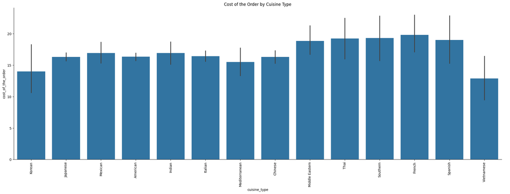

```python
plt.figure(figsize =(15,7));
sns.catplot(data =df, x ='cuisine_type', y ='cost_of_the_order', kind = 'bar', height= 7, aspect = 3);
plt.title('Cost of the Order by Cuisine Type')
plt.xticks(rotation = 90);
plt.show()
```

#### Observations:

**Cat Plot of Cuisine Type and Ratings**

[figure not shown]

```python
plt.figure(figsize =(12, 6));
sns.catplot(data =df, x ='cuisine_type', y ='rating', kind = 'bar', height= 7, aspect = 3);
plt.title('Cuisine Type by rating')
plt.xticks(rotation = 90);
plt.show()
```

#### Observations:

**Bar plot of Average delivery time and Cost of the order**

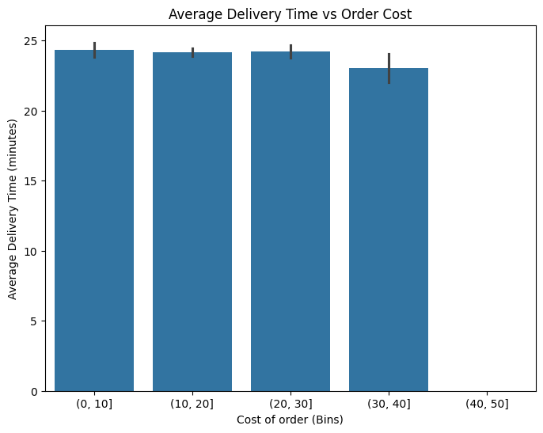

```python
plt.figure(figsize=(8,6))
df['cost_bin'] = pd.cut(df['cost_of_the_order'], bins=[0,10,20,30,40,50])
sns.barplot(data=df, x='cost_bin', y='delivery_time', estimator='mean')
plt.title("Average Delivery Time vs Order Cost")
plt.xlabel("Cost of order (Bins)")
plt.ylabel("Average Delivery Time (minutes)")
plt.show()
```

#### Observations:

From the bar plot above, it is shown that most of the delivery times are the same across all bins, which means the order of the cost doesn't affect the delivery time. Error bars are small too, which means delivery times are consistent across all types of orders. The graph shows that delivery time is not strongly depended on order cost.

### **Question 13:** The company wants to provide a promotional offer in the advertisement of the restaurants. The condition to get the offer is that the restaurants must have a rating count of more than 50 and the average rating should be greater than 4. Find the restaurants fulfilling the criteria to get the promotional offer. [3 marks]

```python
df_rated = df[df['rating'] != 'Not given'].copy()
df_rated['rating'] = df_rated['rating'].astype(float)

restaurant_ratings = df_rated.groupby('restaurant_name')['rating'].agg(['count', 'mean'])

eligible_restaurants = restaurant_ratings[(restaurant_ratings['count'] > 50) & (restaurant_ratings['mean'] > 4)]

print(eligible_restaurants)
```

```
                           count      mean
restaurant_name
Blue Ribbon Fried Chicken     64  4.328125
Blue Ribbon Sushi             73  4.219178
Shake Shack                  133  4.278195
The Meatball Shop             84  4.511905
```

#### Observations:

The restuarants that fullfill the criteria to get the promotional offer are Blue Ribbon Fried Chicken, Blue Ribbon Sushi, Shake Shack, and The Meathball Shop.

### **Question 14:** The company charges the restaurant 25% on the orders having cost greater than 20 dollars and 15% on the orders having cost greater than 5 dollars. Find the net revenue generated by the company across all orders. [3 marks]

```python
def commission(cost_of_the_order):
    if cost_of_the_order > 20:
        return cost_of_the_order * 0.25
    elif cost_of_the_order > 5:
        return cost_of_the_order * 0.15
    else:
        return 0

commission = df['cost_of_the_order'].apply(commission)

net_revenue = commission.sum()

print(f"Net revenue: ${net_revenue:.2f}")
```

```
Net revenue: $6166.30
```

#### Observations:

Net revenue generated by the company across all orders will be 6166.30 dollars.

### **Question 15:** The company wants to analyze the total time required to deliver the food. What percentage of orders take more than 60 minutes to get delivered from the time the order is placed? (The food has to be prepared and then delivered.) [2 marks]

```python
total_time = df['food_preparation_time'] + df['delivery_time']

orders_above_60 = (total_time > 60).sum()

percentage_above_60 = (orders_above_60 / len(df)) * 100

print(f"Percentage of orders taking more than 60 minutes: {percentage_above_60:.2f}%")
```

```
Percentage of orders taking more than 60 minutes: 10.54%
```

#### Observations:

10.54% of orders takes more than 60 minutes to get delivered from the time the order is placed, prepared and delivered.

### **Question 16:** The company wants to analyze the delivery time of the orders on weekdays and weekends. How does the mean delivery time vary during weekdays and weekends? [2 marks]

```python
df.groupby('day_of_the_week')['delivery_time'].mean()
```

| day_of_the_week | delivery_time |
| --- | --- |
| Weekday | 28.340037 |
| Weekend | 22.470022 |

**dtype:** float64

#### Observations:

Time it takes to deliver the order on the weekdays is around 28 minutes and time it takes to deliver the order on the weekends is around 22 minutes.

### Conclusion and Recommendations

### **Question 17:** What are your conclusions from the analysis? What recommendations would you like to share to help improve the business? (You can use cuisine type and feedback ratings to drive your business recommendations.) [6 marks]

### Conclusions:

- There are more orders on the weekends than on weekdays, which means customers don't want to cook on the days off and just want to order food.
- American, Japanese, and Italian cuisines are mostly ordered by the customers.
- Most of the orders are less than 20 dollars, however 29.24% of orders are more than 20 dollars, which are on the expensive side.
- Weekday deliveries take around 28 minutes on average, which is slower than the weekend delivers, which takes around 22 minutes on average.
- The Meatball shop restaurant has the highest average rating of 4.51, following with Shake Shack, Blue Ribbon Sushi, and Blue Ribbon Fried Chicken restaurant.

### Recommendations:

- The cuisines that drive the most demand on the weekends, like American, Japanese and Italian cuisines, the business should focus more on them with weekend specials.
- Cuisines with less popularity, the business should offer more discounts so people order from those restaurants too, generating more revenue, and this should be done more on the weekends, as their is more traffic then.
- The business should promote highly-rated restaurants on their platform, like The Meatball Shop and Shake Shack.
- The business should encourage customers to leave reviews to get better feedback from the customers.
- As seen from the data, 10.54% of orders take more than 60 mins to deliver, the business should focus on those deliveries and reduce that time for better customer satisfaction.
- The business should come up with a strategy to retain the profitable and frequent customers by offering them free delivery or some points per order.